# Demo of scMC using mouse skin dermis scRNA-seq data

Lihua Zhang

26/12/20

We showcase scMC’s capability of detecting context-shared and -specific biological signals by applying it to two mouse skin scRNA-seq datasets containing cells from control and Hedgehog (Hh) activation conditions during skin wound healing.

To make it easy to run scMC in most common scRNA-seq data analysis pipelines, the implementent of scMC is seamlessly compatible with the workflow of Seurat package. In sum, scMC pipeline consists of the following three major parts:

- Set up a list of Seurat objects (one per dataset) and preprocess each dataset seperately
- Perform an integrated analysis using scMC by taking an input a list of Seurat objects
- Run the standard workflow for downstream analyses such as clustering and visualization

## Load the required libraries

```r
library(scMC)
library(Seurat)
library(patchwork)
library(dplyr)
library(ggplot2)
```

## Load data

The scRNA datasets we demonstrated here, including two count data matrices for the control and Hh activation conditions, can be downloaded via this shared Google Drive [link](https://drive.google.com/file/d/182EMDA0x5fr2nV7MbC4SDISSjFBS1E0p/view?usp=sharing).

```r
load("/Users/suoqinjin/Documents/scMC-master/tutorial/data_dermis.rda")
data.input <- data_dermis # a list of count data matrix, one per dataset
sample.name <- names(data.input)
```

# Part I: Set up a list of Seurat objects, one per dataset

```r
object.list <- vector("list", length(sample.name))
names(object.list) <- sample.name
for (i in 1:length(object.list)) {
  # Initialize the Seurat object with the raw (non-normalized data) for each dataset
  x <- CreateSeuratObject(counts = data.input[[i]], min.cells = 3, min.features = 200, project = sample.name[i])
  # calculate mitochondrial QC metrics
  x[["percent.mt"]] <- PercentageFeatureSet(x, pattern = "^mt-")
  x$sample.name <- sample.name[i]
  x <- RenameCells(x, new.names = paste0(Cells(x), "_", x$sample.name))
  object.list[[i]] <-  x
  rm(x)
}
lapply(object.list, function(x) dim(x@assays$RNA@data))
```

```
#> $Control
#> [1] 17099  2878
#>
#> $`Hh activation`
#> [1] 16119  1802
```

## Step1. preprocess each dataset seperately

### QC and selecting cells for further analysis

```r
nFeature_RNA1 = c(7000, 7000); nCount_RNA1 = c(40000, 40000); percent.mt1 = c(10, 10)
for (i in 1:length(object.list)) {
  # Visualize QC metrics as a violin plot
 VlnPlot(object.list[[i]], features = c("nFeature_RNA", "nCount_RNA", "percent.mt"), ncol = 3, pt.size = 0.0001,cols=c("#a6cee3")) + geom_hline(yintercept = percent.mt1[i], linetype = 2)
 # VlnPlot(object.list[[i]], features = c("percent.mt"))+ geom_hline(yintercept = 15, linetype = 2)
  Sys.sleep(2)
  plot1 <- FeatureScatter(object.list[[i]], feature1 = "nCount_RNA", feature2 = "percent.mt", pt.size = 0.1,cols=c("black")) + geom_hline(yintercept = percent.mt1[i], linetype = 2)
  plot2 <- FeatureScatter(object.list[[i]], feature1 = "nCount_RNA", feature2 = "nFeature_RNA", pt.size = 0.1,cols=c("black")) + geom_hline(yintercept = nFeature_RNA1[i], linetype = 2)
wrap_plots(plots = plot1, plot2, ncol = 2)
  object.list[[i]] <- subset(object.list[[i]], subset = (nFeature_RNA < nFeature_RNA1[i]) & (nCount_RNA < nCount_RNA1[i]) & (percent.mt < percent.mt1[i]))
}
lapply(object.list, function(x) dim(x@assays$RNA@data))
```

```
#> $Control
#> [1] 17099  2847
#>
#> $`Hh activation`
#> [1] 16119  1792
```

```r
# save the Seurat object of each dataset (optional)
save(object.list, file = "SeuratObject.list_dermis.RData")
```

### Normalizing, scaling the data and feature selection

```r
object.list <- lapply(X = object.list, FUN = function(x) {
  x <- NormalizeData(x, verbose = FALSE)
  x <- FindVariableFeatures(x, verbose = FALSE)
  # perform scaling on the previously identified variable features
  x <- ScaleData(x, verbose = FALSE)
})
```

# Part II: Perform an integrated analysis using scMC

**Note**: We have wrritten a Seurat Wrapper function `RunscMC` to simply run the following Steps 2-6. That is, users can run `combined <- RunscMC(object.list)` to replace the Steps 2-6. See the tutorial “demo_scMC_Seurat_Wrapper_dermis” for details.

```r
future::plan("multiprocess", workers = 4)
options(future.rng.onMisuse="ignore")
```

## Step2. Identify putative clusters for each dataset

```r
# compute SNN
object.list <- identifyNeighbors(object.list)
```

```
#> Performing PCA in Dataset  1
#> Building SNN on the PCA space in Dataset  1
#> Performing PCA in Dataset  2
#> Building SNN on the PCA space in Dataset  2
```

```r
# identify clusters
object.list <- identifyClusters(object.list)
```

```
#> Identifying cell clusters in Dataset 1
#> Peforming hierarchical clustering on the computed consensus matrix
#> The initial guessed number of clusters is 17
#> Identifying cell clusters in Dataset 2
#> Peforming hierarchical clustering on the computed consensus matrix
#> The initial guessed number of clusters is 15
```

## Step3. Detect cluster-specific cells with high confident

```r
features.integration = identifyIntegrationFeatures(object.list)
object.list <- identifyConfidentCells(object.list, features.integration)
```

## Step4. Identify marker genes associated with the putative cell clusters in each dataset

```r
object.list <- identifyMarkers(object.list)
```

```
#> Identifying marker genes of cell clusters in Dataset 1
#> Identifying marker genes of cell clusters in Dataset 2
```

## Step 5. Learn technical variation between any two datasets

```r
structured_mat <- learnTechnicalVariation(object.list, features.integration)
```

## Step 6. Learn a shared embedding of cells across all datasets after removing technical variation

```r
combined <- merge(x = object.list[[1]],y = object.list[2:length(x = object.list)])
combined@meta.data <- combined@meta.data %>% select(-starts_with("RNA_snn_res"))
combined$sample.name <- factor(combined$sample.name, levels = sample.name)
VariableFeatures(combined) <- features.integration
combined <- integrateData(combined, structured_mat) # return an updated Seurat object with a new reduced dimensional space named "scMC"
```

scMC outputs a shared reduced dimensional embedding of cells that retains the biological variation while removing the technical variation. This shared embedding can be used for a variety of single cell analysis tasks, such as low-dimensional visualization, cell clustering and pseudotemporal trajectory inference.

# Part III: Run the standard Seurat workflow for downstream analyses such as clustering and visualization

We can now run standard Seurat workflow for downstream analyses. Users only need to make one change to your code, i.e., using the scMC embeddings instead of PCA.

## Run the standard workflow for clustering

```r
nPC = 40
combined <- FindNeighbors(combined, reduction = "scMC", dims = 1:nPC)
# scMC uses Leiden algorithm for clustering by default. However, users can also use other algorithms inplemented in Seurat
combined <- FindClusters(combined, algorithm = 4, resolution = 0.05)
combined <- BuildClusterTree(combined, reorder = T, reorder.numeric = T, verbose = F)
combined <- RunUMAP(combined, reduction='scMC', dims = 1:nPC)
```

### Quick visualization of cells onto the low-dimensional space

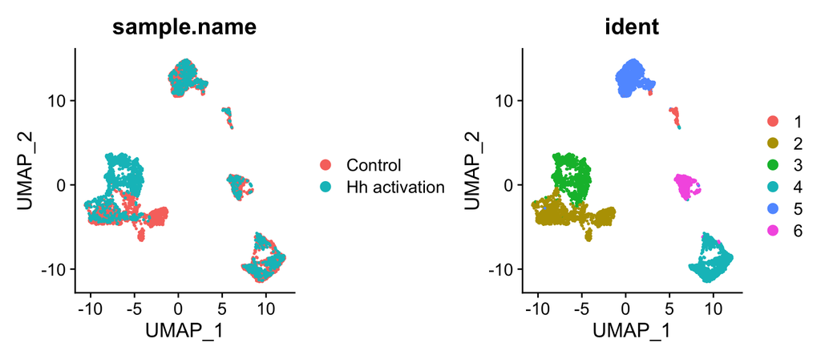

```r
DimPlot(combined, reduction = "umap", group.by = c("sample.name","ident"))
```

## Visualization and annotation

### Feature plot of known marker genes

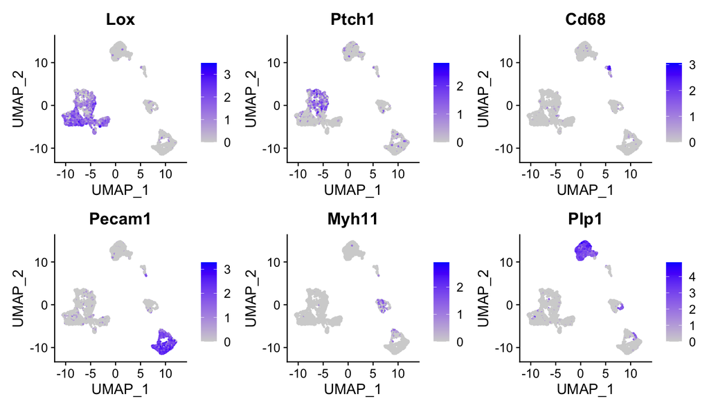

```r
features = c('Lox','Ptch1','Cd68','Pecam1','Myh11','Plp1')
FeaturePlot(combined, features = features, ncol = 3)
```

### Annotation

```r
new.cluster.ids <-c("Immune", "Hh-inactive Fib", "Hh-active Fib",  "Endotheial", "Schwann","Muscle")
names(new.cluster.ids) <- levels(combined)
combined <- RenameIdents(combined, new.cluster.ids)
new.order <- c("Hh-inactive Fib", "Hh-active Fib","Immune","Endotheial", "Muscle", "Schwann")
combined@active.ident <- factor(combined@active.ident, levels = new.order)
```

### Visualize cells onto the low-dimensional space

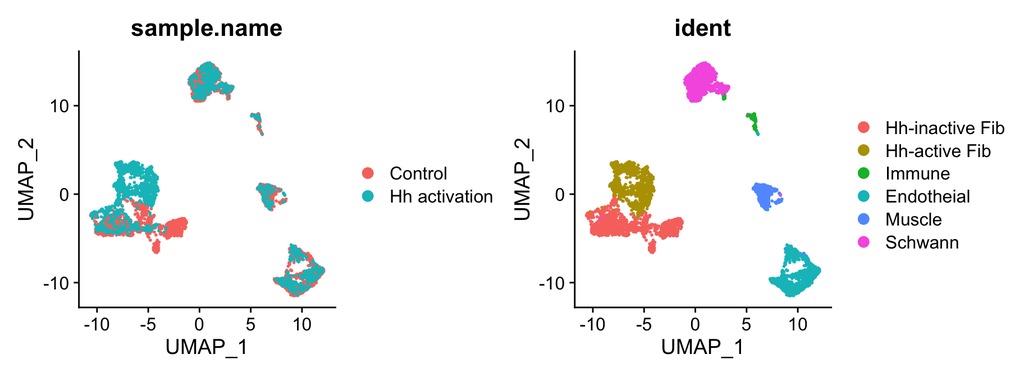

```r
DimPlot(combined, reduction = "umap", group.by = c("sample.name", "ident"))
```

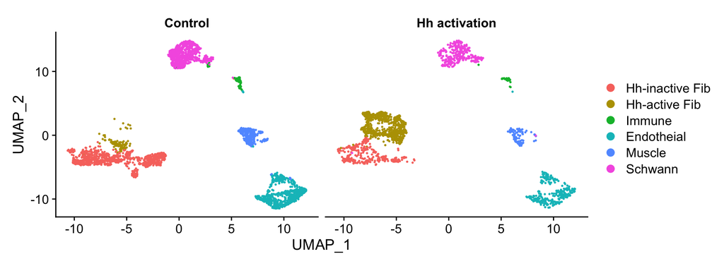

```r
# Split the plot into each dataset
DimPlot(combined, reduction = "umap", split.by = "sample.name")
```

### Heatmap of marker genes

```r
combined <- ScaleData(combined, feature = rownames(combined), verbose = FALSE)
markers <- FindAllMarkers(combined, only.pos = TRUE, min.pct = 0.25, logfc.threshold = 0.25)
```

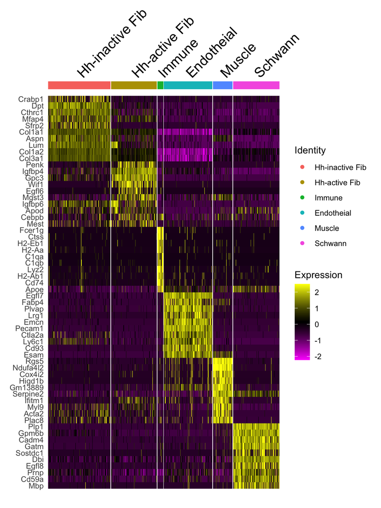

```r
top10 <- markers %>% group_by(cluster) %>% top_n(n = 10, wt = avg_log2FC)
DoHeatmap(combined, features=top10$gene)
```

### Violin plot

#### Stacked violin plot

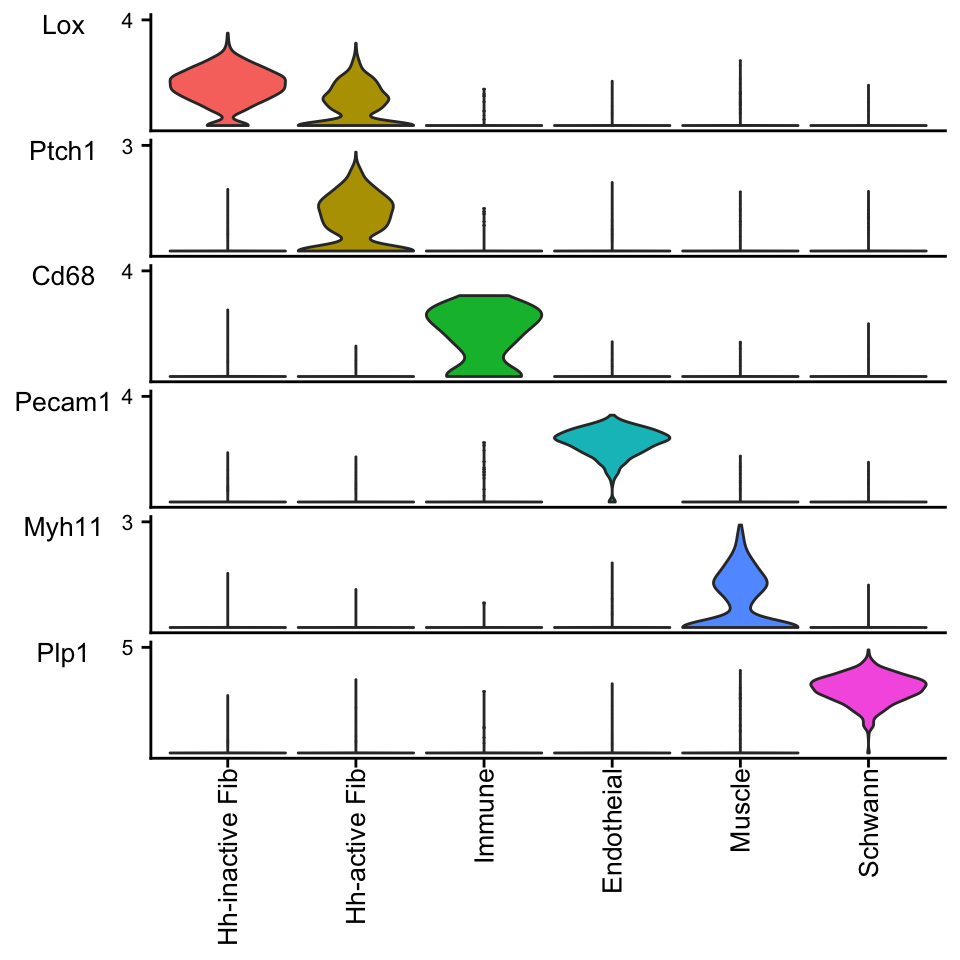

```r
features = c('Lox','Ptch1','Cd68','Pecam1','Myh11','Plp1')
gg <- StackedVlnPlot(combined, features = features, colors.ggplot = T)
gg
```

#### Splitted violin plot

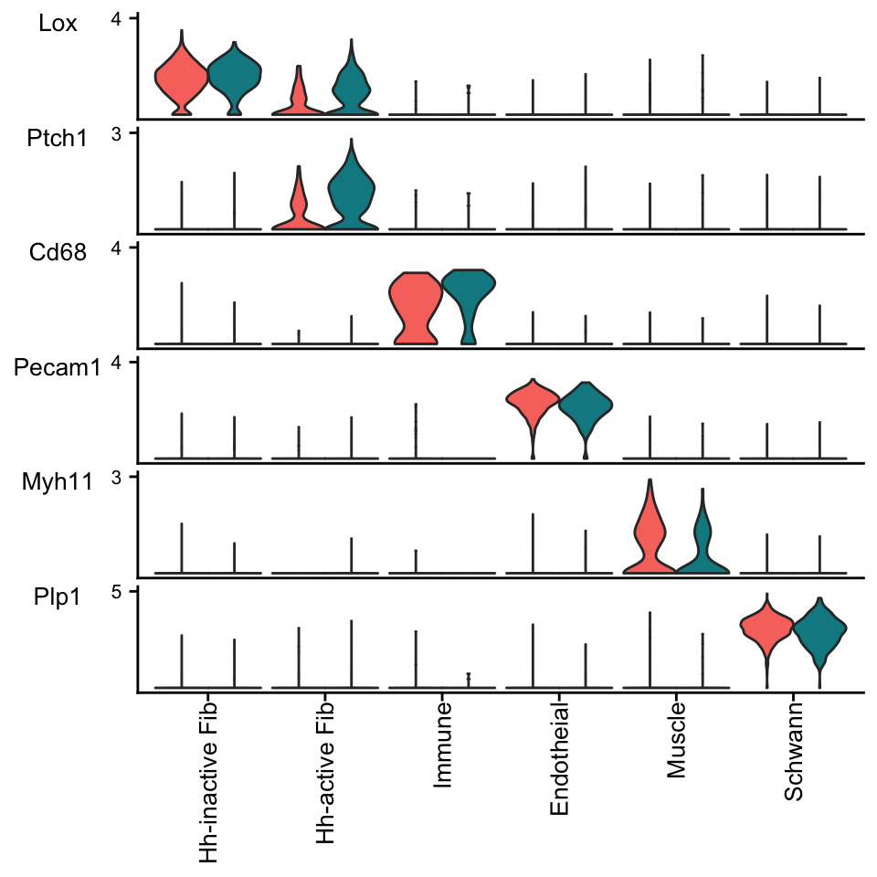

```r
features = c('Lox','Ptch1','Cd68','Pecam1','Myh11','Plp1')
gg <- StackedVlnPlot(combined, features = features, split.by = "sample.name", colors.ggplot = T)
gg
```

# Part IV: Downstream analysis

```r
combined$clusters.final <- Idents(combined)
```

## Compute the cellular compositions

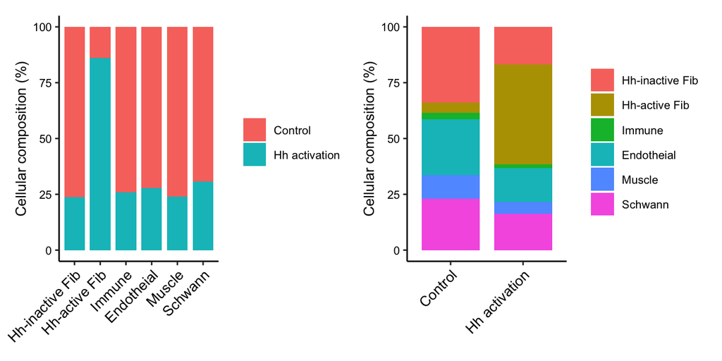

```r
gg1 <- computeProportion(combined, x = "clusters.final", fill = "sample.name")
gg2 <- computeProportion(combined, x = "sample.name", fill = "clusters.final")
gg1 + gg2
```

# Save data

```r
combined <- ScaleData(combined) # only store the highly variable genes
save(combined, file = "demo_scMC_dermis.RData")
```